# ESM244 Assignment 2 Task 2: Binary Logistic Regression

Grace Brofman

2/8/2021

## **Introduction**

The Environmental Data Initiative [(EDI)](https://portal.edirepository.org/nis/mapbrowse?packageid=edi.317.1) provides datasets pertaining to Serenoa repens and Sabal etonia, the two dominant palemtto species at Florida’s Archbold Biological Station. This report utilizes data specific to survival, growth, and biomass estimates for the two palmetto species from 1981 - 2017. After initial expoloratory visualizations, a binary logistic regression is performed for several variables as predictors of palmetto species, followed by an evaluation of this model as a predictor tool.

### **Section 1:** Exploratory visualizations

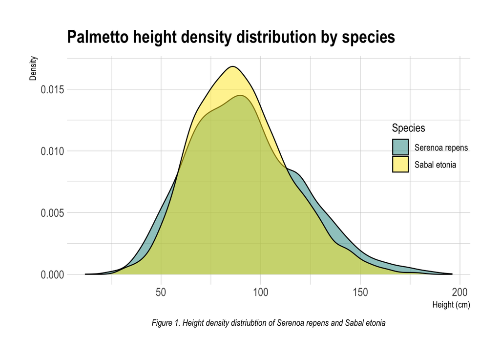

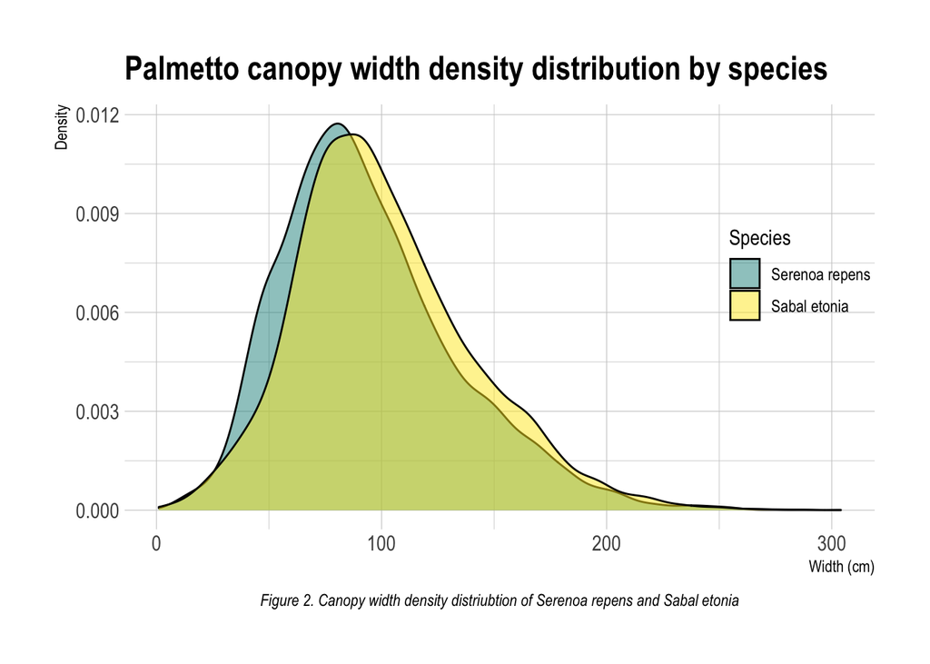

- Comparison of canopy width density distribution by species shows significant overlap in distribution.

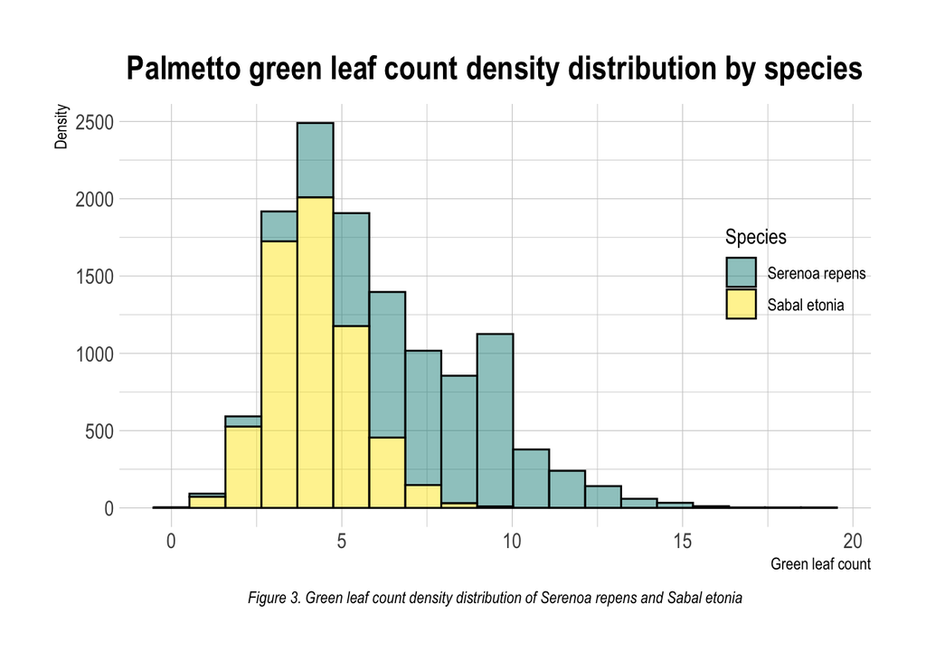

- Histogram density comparison of green leaf count shows divergent trends between the two species. Broadly, it appears that Serenoa repens tends to have more green leaves than Sabal etonia.

### **Section 2:** Binary logistic regression

In this section, a binary logistic regression is performed using plant height, canopy length, canopy width, and green leaf count as predictor values for species.

| Table 1. Binary logistic regression results. Note that P-values are <<0.5, thus appearing as zero. Note that the reference species is Serenoa repens Coefficients | Table 1. Binary logistic regression results. Note that P-values are <<0.5, thus appearing as zero. Note that the reference species is Serenoa repens Estimate | Table 1. Binary logistic regression results. Note that P-values are <<0.5, thus appearing as zero. Note that the reference species is Serenoa repens Standard Error | Table 1. Binary logistic regression results. Note that P-values are <<0.5, thus appearing as zero. Note that the reference species is Serenoa repens Statistic | Table 1. Binary logistic regression results. Note that P-values are <<0.5, thus appearing as zero. Note that the reference species is Serenoa repens P-value |
| --- | --- | --- | --- | --- |
| (Intercept) | 3.2266851 | 0.1420708 | 22.71180 | 0 |
| height | -0.0292173 | 0.0023061 | -12.66984 | 0 |
| length | 0.0458233 | 0.0018661 | 24.55600 | 0 |
| width | 0.0394434 | 0.0021000 | 18.78227 | 0 |
| green_lvs | -1.9084747 | 0.0388634 | -49.10728 | 0 |

### **Section 3:** Model classification table

| Table 2. Prediction model outcome success counts and percentages Species | Table 2. Prediction model outcome success counts and percentages Correctly Classified | Table 2. Prediction model outcome success counts and percentages Incorrectly Classified | Table 2. Prediction model outcome success counts and percentages Percent Correctly Classified |
| --- | --- | --- | --- |
| Sabal_etonia | 5701 | 454 | 92.62388 |
| Serenoa_repens | 5548 | 564 | 90.77225 |

### **Conclusion**

Some main takeaways from this report include:

- Based on exploratory visualizations and coefficient values, green leaf count appears to be the best predictor variable for palmetto species, with more green leaves indicating a higher likelihood that the species is Serenoa repens.
- The model created using binary logistic regression is a relatively good predictor of palmetto species, however, the model will still misclassify species on occasion.

### **References**

**Abrahamson, W.G.** 2019. Survival, growth and biomass estimates of two dominant palmetto species of south-central Florida from 1981 - 2017, ongoing at 5-year intervals ver 1. Environmental Data Initiative. https://doi.org/10.6073/pasta/f2f96ec76fbbd4b9db431c79a770c4d5